# AD2 - Problema 1

Lilia Sampaio

October 15, 2014

**Questão 1**

Ao tentar responder a questão sobre a existência de dois mundos, o ocidental norte rico e o resto do mundo pobre, Hans traça um caminho analisando os dados e percorrendo vários aspectos que de alguma maneira são de relevância para a questão. Escolher que aspectos são esses, é portanto, o primeiro passo.

Assim, Hans começa expondo um gráfico de pontos, onde cada ponto representa um país, e tem o tamanho proporcinal à população desse país. O aspecto analisado é a expectativa de vida versus a quantidade de filhos por mulher no dado país. Os dados são analisados no decorrer de um espaço de tempo, e mostra que, com o passar dos anos, países mais ricos e pobres, passam a ocupar o mesmo lugar no gráfico, com famílias pequenas e expectativa de vida longa.

Outro aspecto é então analisado. Qual a distribuição de renda no mundo também com o passar do tempo. Um gráfico de densidade é então utilizado para mostrar onde está a população no que se refere a quantidade de dolars recebido por dia. Esse aspecto leva a outro, qual a relação da taxa de sobrevivencia de recém nascidos com a renda per capita do país. Outro gráfico de pontos similar ao primeiro é utilizado.

Finalmente, Hans destaca o perigo ao se usar a média como métrica para analisar o conjunto de dados, pois uma mesma região do mundo pode ser bastante diferente em suas áreas e podem, em outras palavras, portanto, ter seu resultado influenciado por outliers.

**Questão 2**

Observando os dados, consegue-se destacar alguns campos da tabela que podem ser considerados bons indicadores do atual panorama geral do profissional de TI no Brasil, sendo eles, por exemplo, *Região*, *Horas diárias*, *Experiência Profissional*, *Cargo* e *Formação*. Outros indicadores também poderiam ser incluídos nessa análise, porém considerando o objetivo da mesma como sendo uma visão geral da situação dos profissionais, entende-se que os dados selecionados são suficientes.

Considere *salarios* como sendo a tabela contendo os dados (162 observações) e *Regiao*, *Horas.Diarias*, *Experiencia.Profissional*, *Cargo* e *Formacao* as referentes colunas. As conclusões foram como segue:

```r
#Importando o dataset
salarios = read.csv("salarios-ti-regioes.csv")
```

1. Analisando o gráfico a seguir percebemos que a maior concentração de profissionais de TI no Brasil encontra-se na região Sudeste e Nordeste. Significa dizer que o maior número de oportunidades na área podem ser encontradas nessas regiões, por exemplo.

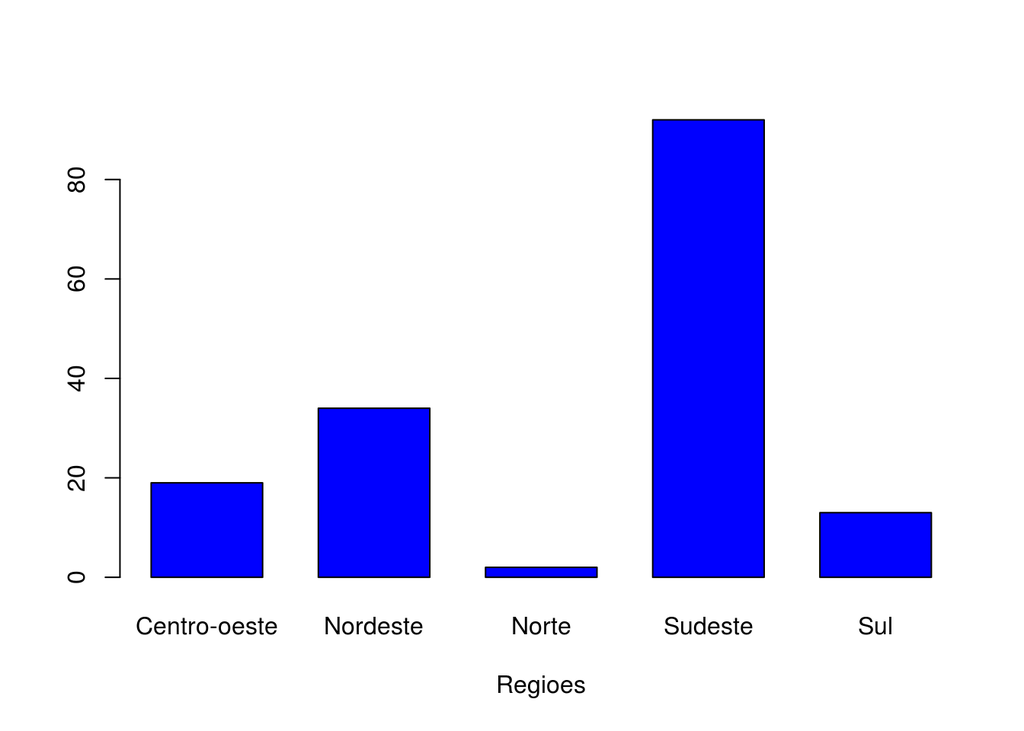

```r
regioes <- table(salarios$Regiao)
barplot(regioes, width = .1, space = .5, col = c("blue"), xlab = "Regioes")
```

Se quisermos um sumário detalhado acerca dos números de cada região, ou seja, a quantidade exata de profissionais considerando o conjunto de dados analisados, temos os números a seguir:

```r
summary(salarios$Regiao)
```

```
## Centro-oeste     Nordeste        Norte      Sudeste          Sul
##           19           34            2           92           13
##         NA's
##            2
```

2. Os profissionais de TI no Brasil trabalham em média **7.885679 horas** por dia.

```r
#Calculando a média de horas diárias
mean(salarios$Horas.Diarias)
```

```
## [1] 7.885679
```

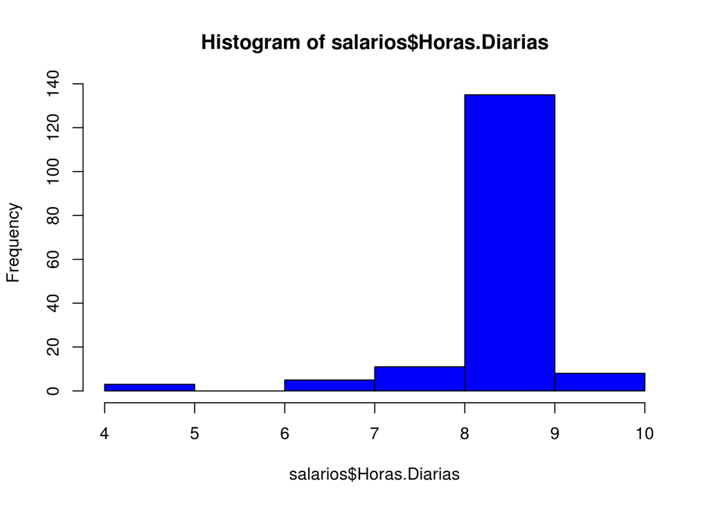

```r
horas<- 4:10
hist(salarios$Horas.Diarias, breaks=horas, right=FALSE, col="blue")
```

3. Considerando o tempo de trabalho em anos, a experiência profissional é dada por **5.530185** em média.

```r
#Calculando a média da experiência profissional
mean(salarios$Experiencia.Profissional)
```

```
## [1] 5.530185
```

**Questão 3**

Podemos ter uma visão sumarizada da configuração salarial do profissional de TI no Brasil, considerando os dados utilizados, abaixo:

```r
summary(salarios$Salario.Bruto)
```

```
##    Min. 1st Qu.  Median    Mean 3rd Qu.    Max.
##     500    2281    3583    4233    5332   42120
```

Vemos que a variação de salário no grupo estudado está entre um mínimo de R$500,00 e um máximo de R$42.120,00. Podemos dizer que esta é uma grande variação, mas, considerando o conjunto de dados como um todo vemos que apesar dessa discrepância, a maioria dos salários encontra-se no intervalo 0-5000, como podemos ver no histograma a seguir.

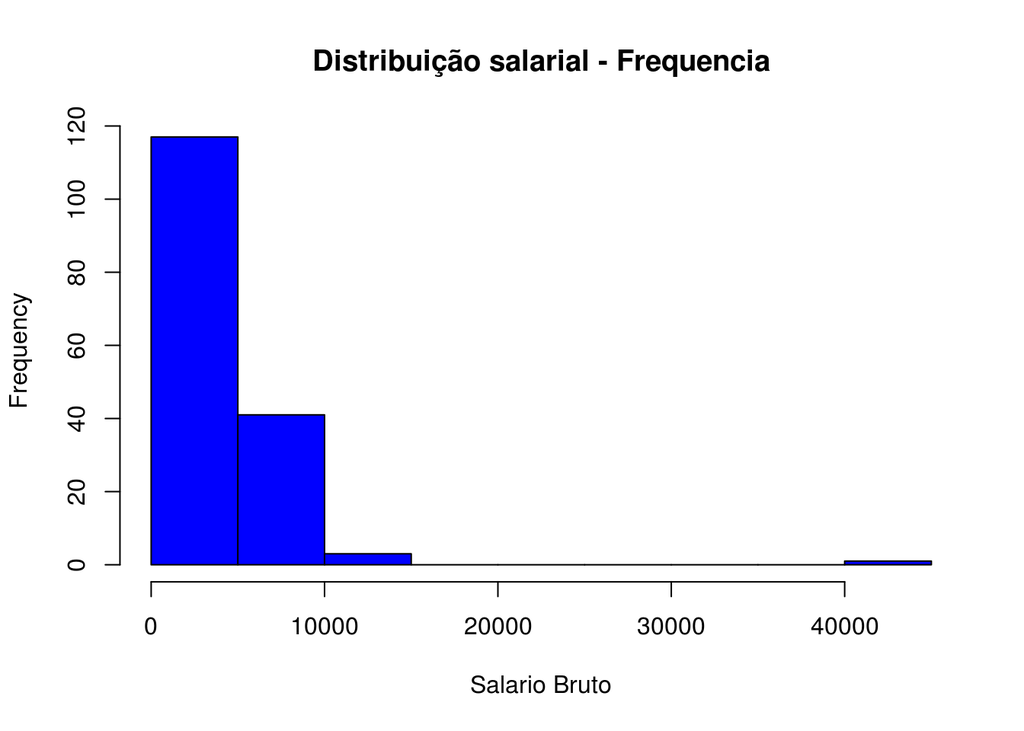

```r
histinfo <- hist(salarios$Salario.Bruto, main = "Distribuição salarial - Frequencia", col = c("blue"), xlab = "Salario Bruto")
```

Mais precisamente, considerando os intervalos assumidos como

```r
histinfo$breaks
```

```
##  [1]     0  5000 10000 15000 20000 25000 30000 35000 40000 45000
```

e a quantidade de casos incluidos em cada intervalo como

```r
histinfo$count
```

```
## [1] 117  41   3   0   0   0   0   0   1
```

vemos que um número de 117 casos encontra-se no intervalo 0-5000. Para confirmar o presumido de que a maioria dos casos encontra-se nessa faixa de salários, podemos analisar a densidade de cada intervalo no gráfico de densidades dado abaixo:

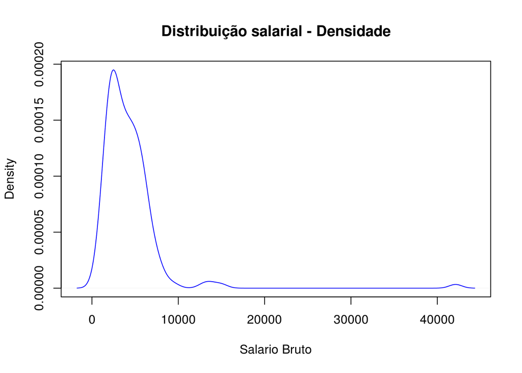

```r
d<-density(salarios$Salario.Bruto)
plot(d, main = "Distribuição salarial - Densidade", col = c("blue"), xlab = "Salario Bruto")
```

Apenas avaliando os gráficos acima, já conseguimos perceber que valores em alguns intervalos tem frequência e densidade quase nenhuma, diferindo bastante do grupo predominante. A esses valores damos o nome de outliers. Alguns gráficos conseguem ser mais específicos acerca de possíveis outliers, como podemos ver no `boxplot` a seguir, que nos mostra a presença de 4 outliers (pontos circulares) no conjunto de dados estudado.

```r
summary(salarios$Salario.Bruto)
```

```
##    Min. 1st Qu.  Median    Mean 3rd Qu.    Max.
##     500    2281    3583    4233    5332   42120
```

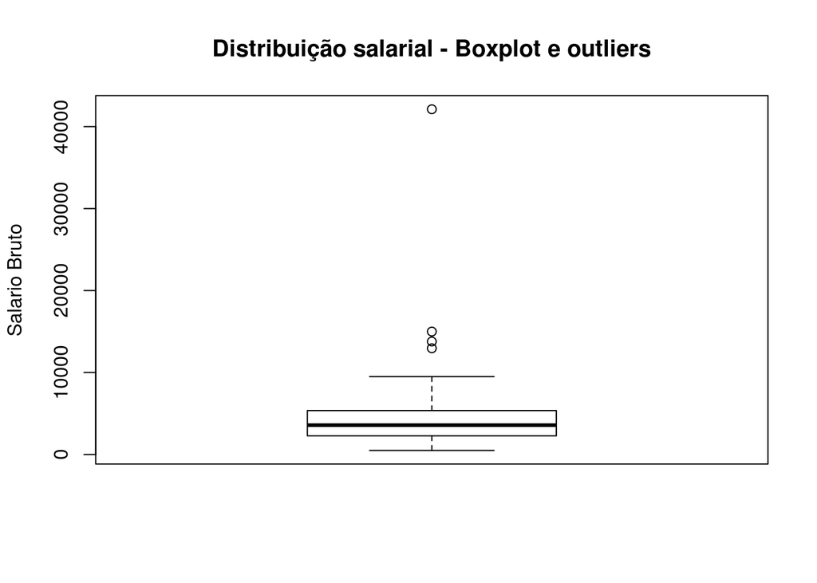

```r
boxplot(salarios$Salario.Bruto, main = "Distribuição salarial - Boxplot e outliers", ylab = "Salario Bruto")
```

**Questão 4**

A distribuição encontrada é em parte como esperada. Com o cenário atual, essa distribuição concentrada entre os valores de 0-5000 e 5000-10000 atende à minha suposição inicial sem conhecimento dos dados apresentados. Assim, ao analisar os dados, pudemos comprovar tal suposição, mas a presença de outliers tão mais altos foram, em parte, uma surpresa. É certo que, ao realizar uma pesquisa e análise de dados como essa, é esperado que outliers possam aparecer eventualmente, mas, ao meu ver, a discrepância foi um tanto quanto grande demais nesse caso.

**Questão 5**

Na tabela abaixo podemos ver a média salarial do profissional de TI no Brasil em cada uma de suas regiões, ordenadas da maior média para a menor.

```r
media.regiao <- tapply(salarios$Salario.Bruto, salarios$Regiao, mean)
sort(media.regiao, decreasing=TRUE)
```

```
## Centro-oeste     Nordeste      Sudeste          Sul        Norte
##     5620.474     4565.706     3962.227     3657.538     2552.500
```

Salvamos então a tabela executando

```r
write.csv(media.regiao, file="salario-regiao.csv")
```

Caso tivéssimos utilizado a métrica **mediana** ao invés da *média*, teríamos o seguinte resultado:

```r
mediana.regiao <- tapply(salarios$Salario.Bruto, salarios$Regiao, median)
sort(mediana.regiao, decreasing=TRUE)
```

```
## Centro-oeste      Sudeste          Sul     Nordeste        Norte
##      5000.00      3582.95      3500.00      2900.00      2552.50
```

Nesse caso, a ordem de maior média salarial muda de **Centro-oeste, Nordeste, Sudeste, Sul e Norte** para **Centro-oeste, Sudeste, Sul Nordeste e Norte**.

Isso se dá pois quando calculamos a média com a função `mean`, esse valor é obtido somando-se todos os valores do conjunto e dividindo o resultado pelo número de observações considerado, ou seja, uma média regular, que considera **todos** os valores do conjunto, inclusive possiveis outliers. O resultado dessa operação pode ser, portanto, bastante influenciado por tais outliers caso eles sejam muito maiores ou muito menores que o restante dos valores considerados.

Ao utilizar a mediana com a função `median`, por outro lado, o resultado é obtido ordenando-se os valores, e encontrando apenas o valor que está exatamente no meio do conjunto, sendo este considerado como mediana dos dados sendo observados.

**Questão 6**

Considerando o que foi descoberto na questão anterior, temos que a região com melhor média salarial é a Centro-Oeste. Portanto, profissinais que não estejam localizados nessa região, por exemplo, tem a chance de melhorar seu salário buscando oportunidades lá.

Seguindo essa mesma lógica de cruzamento de dados, podemos cruzar *Salario.Bruto* com *Cargo* e ter uma ideia das posições de profissionais de TI que estão pagando melhor de acordo com os dados utilizados. Teríamos, portanto, como segue

```r
media.cargo <- tapply(salarios$Salario.Bruto, salarios$Cargo, mean)
```

Ordenando esse conjunto, temos por exemplo que os três cargos com maiores salários são *Analista de Suporte*, *Consultor PNUD/GP* *Governança de TI*. Outros cargos ainda se destacam, como podemos ver abaixo.

```r
sort.media.cargo <- sort(media.cargo, decreasing=TRUE)
head(sort.media.cargo)
```

```
##                         Analista de Suporte
##                                       22810
##                           Consultor PNUD/GP
##                                       15000
##                            Governança de TI
##                                       13787
## Arquiteto de sistemas, Java/Oracle/J2EE/Web
##                                        8500
##                                       COBOL
##                                        8000
##      Analista de Sistemas / Lider de equipe
##                                        7680
```

Ainda seguindo a mesma linha, podemos cruzar *Salario.Bruto* com *Pos.Graduacao.ou.Certificacao*, tendo, portanto,

```r
tapply(salarios$Salario.Bruto, salarios$Pos.Graduacao.ou.Certificacao, mean)
```

```
##    FALSE     TRUE
## 3369.000 5119.599
```

Com isso, vemos que a média salarial do profissional que possui uma certificação ou pos-gradução é maior que a de quem não possui.

A análise desses aspectos já é capaz de prover boas informações para profissionais de TI buscando ser melhor pago em suas funções, por exemplo.